# Project 1: Can Certain Release Points Lead to Greater Pitching Success in the MLB?

By: Jonathan Dietrich, Conner Toryfter & Karan Kapur

## Executive Summary

In Major League Baseball, gaining a competitive edge on opponents through pitching relates to knowing what aspects allow a pitcher to be successful. For our project, we set out to explore whether a pitcher’s release point, the location where the ball leaves the pitcher’s hand, defined by its horizontal distance and vertical height from home plate, has any correlation with better performance. Our goal was to analyze key stats like Earned Run Average (ERA), Fielding Independent Pitching (FIP), Walks plus Hits per Inning Pitched (WHIP), and Strikeout-to-Walk ratio (K/BB), across various release points. Using 2025 MLB season data, we grouped pitchers based on their release points to see if certain release points lead to superior results, aiming to find an ideal release point range that would provide insights for player development and coaching, in the hope of developing more successful pitchers.

Our findings deepen this exploration, indicating that for left-handed pitchers, a further and higher release point might optimize success, despite horizontal and vertical variations having minimal impact on ERA, WHIP, FIP, or K/BB%. This suggests that focusing player development on left-handers who throw from extended and elevated positions could enhance their MLB prospects, while scouts might prioritize such profiles for a slight performance boost. For right-handed pitchers, we noted marginally higher ERA and FIP, but shifts in horizontal and vertical release depths didn’t significantly alter these stats. Notably, the standout group of left-handed pitchers, with a mean release distance exceeding 2.088 feet and height above 5.753 feet, included top performers like Trevor Rogers, who holds an impressive 1.81 ERA, and Garrett Crochet, a 2025 CY-Young candidate with a 2.59 ERA, highlighting that a potential ideal release point is similar to guys of this sort. However, when looking past the base metrics used to compare the pitchers, we found very little to no statistical significance to back whether a certain release point group was more successful. However, it was found that left-handed pitchers in general yield more success in the MLB in the metrics we dug into.

These insights can guide teams to refine pitching mechanics or scout for specific release point traits that align with success. Still, we recognize the need for more study, considering factors like pitch velocity or spin rate, and incorporating data from past seasons would only enhance our conclusions. Additionally, exploring how release points interact with a pitcher’s physical build or delivery style might reveal new advantages or even potential disadvantages, while testing these findings across different ballparks could uncover environmental influences. This broader approach could lead teams to more efficient development plans, ensuring a more comprehensive strategy for creating future pitching success.

## Technical Summary

### Data Collection

We wanted to look at data from all pitches during the 2025 MLB regular season. We used the modified version of Bill Petti’s statcast scraper from lecture 6 to scrape the pitch by pitch data for the season. Because this code takes over an hour to run, we decided not to include it in this file, but saved the data as raw_statcast2025.RData, and loaded it in below. We then found the average x and z depth for each pitcher across all of their pitches for the season. Lastly, we used the bref_daily_pitcher function to scrape season long statistics for each pitcher from Baseball Reference, and joined this with the release data we had already.

### Comparisons

We then wanted to compare how the different release points affected different statistics like ERA, WHIP, FIP and K/BB. The data did not have FIP so we calculated that ourselves. After, we split the data between left and right handed pitchers, and then grouped their releases into either further or closer, and higher or lower, creating 8 different release point groups. We then looked at how the ERA, WHIP, FIP, and K/BB changed across groups when we grouped by only handedness, only x_depth, only z_depth, and all of them together.

```r
all_pitcher_stats = named_releases %>% left_join(bbref, by = "bbref_id") %>% group_by(throwing_hand) %>% mutate(x_depth = ifelse(abs(avg_rel_x) > abs(mean(avg_rel_x)), "Further", "Closer")) %>% mutate(z_depth = ifelse(avg_rel_z > mean(avg_rel_z), "Higher", "Lower")) %>% mutate(FIP = round(((13 * HR + (3 * (BB + HBP)) - (2 * SO)) / IP) + 3.14, 3))

nums4 = named_releases %>% left_join(bbref, by = "bbref_id") %>% group_by(throwing_hand) %>% summarize(x_avg = mean(avg_rel_x), z_avg = mean(avg_rel_z))

final_pitchers = all_pitcher_stats %>% select(Name.x, throwing_hand, IP, avg_rel_x, avg_rel_z, x_depth, z_depth, ERA, WHIP, FIP, SO.W) %>% filter(!is.na(ERA), !is.na(WHIP), !is.na(FIP), !is.na(SO.W)) %>% ungroup() %>% filter(IP > 9)

all_pitchers_means = final_pitchers %>% summarize(mean_era = mean(ERA), mean_whip = mean(WHIP), mean_fip = mean(FIP), mean_sow = mean(SO.W), count = n())

groupings = final_pitchers  %>% group_by(throwing_hand, x_depth, z_depth, avg_rel_x, avg_rel_z) %>% summarize(mean_era = mean(ERA), mean_whip = mean(WHIP), mean_fip = mean(FIP), mean_sow = mean(SO.W), count = n()) %>% mutate(Category = paste(x_depth, z_depth, throwing_hand))
```

```
## 'avg_rel_x'. You can override using the `.groups` argument.
```

```r
grouped_by_hand = final_pitchers %>% ungroup() %>% group_by(throwing_hand) %>% summarize(mean_era = mean(ERA), mean_whip = mean(WHIP), mean_fip = mean(FIP), mean_sow = mean(SO.W), count = n())

grouped_by_xdepth = final_pitchers %>% ungroup() %>% group_by(x_depth) %>% summarize(mean_era = mean(ERA), mean_whip = mean(WHIP), mean_fip = mean(FIP), mean_sow = mean(SO.W), count = n())

grouped_by_zdepth = final_pitchers %>% ungroup() %>% group_by(z_depth) %>% summarize(mean_era = mean(ERA), mean_whip = mean(WHIP), mean_fip = mean(FIP), mean_sow = mean(SO.W), count = n())

combined_groups = final_pitchers  %>% group_by(throwing_hand, x_depth, z_depth) %>% summarize(mean_era = mean(ERA), mean_whip = mean(WHIP), mean_fip = mean(FIP), mean_sow = mean(SO.W), count = n()) %>% mutate(Category = paste(x_depth, z_depth, throwing_hand))
groupings_no_hand = final_pitchers  %>% group_by(x_depth, z_depth) %>% summarize(mean_era = mean(ERA), mean_whip = mean(WHIP), mean_fip = mean(FIP), mean_sow = mean(SO.W), count = n()) %>% mutate(Category = paste(x_depth, z_depth))
```

### Plots

Our first two graphs show how we first separated the pitchers into right versus left-handed and then into one of the four quadrants on that side.

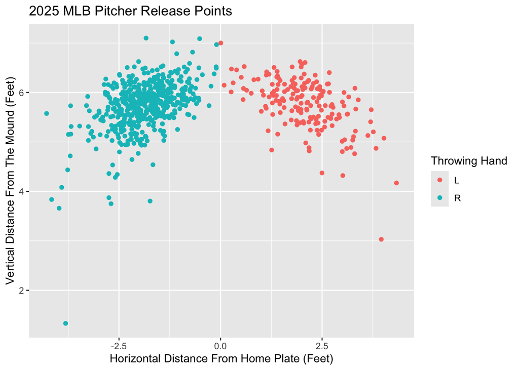

```r
release_positions = ggplot(final_pitchers, aes(x = avg_rel_x, y = avg_rel_z, color = throwing_hand)) + geom_point() + labs(x = "Horizontal Distance From Home Plate (Feet)", y ="Vertical Distance From The Mound (Feet)", title = "2025 MLB Pitcher Release Points", color = "Throwing Hand" )
release_positions
```

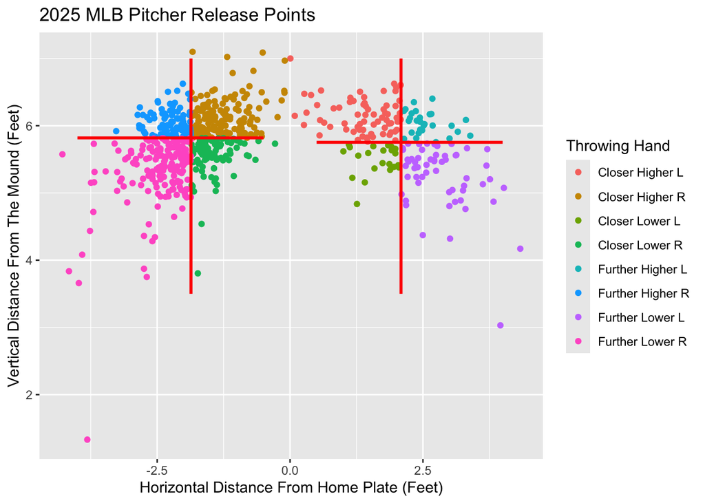

```r
release_positions = ggplot(groupings, aes(x = avg_rel_x, y = avg_rel_z, color = Category)) + geom_point() + labs(x = "Horizontal Distance From Home Plate (Feet)", y ="Vertical Distance From The Mound (Feet)", title = "2025 MLB Pitcher Release Points", color = "Throwing Hand" ) + annotate("segment", x = 0.5, xend = 4, y = nums4$z_avg[1], yend = nums4$z_avg[1], color = "red", linetype = "solid", size = 1) + annotate("segment", x = -4, xend = -0.5, y = nums4$z_avg[2], yend = nums4$z_avg[2], color = "red", linetype = "solid", size = 1) + annotate("segment", x = nums4$x_avg[1], xend = nums4$x_avg[1], y = 3.5, yend = 7, color = "red", linetype = "solid", size = 1) + annotate("segment", x = nums4$x_avg[2], xend = nums4$x_avg[2], y = 3.5, yend = 7, color = "red", linetype = "solid", size = 1)
release_positions
```

We wanted to see if ERA and FIP had any sort of correlation with what release point group a pitcher was in.

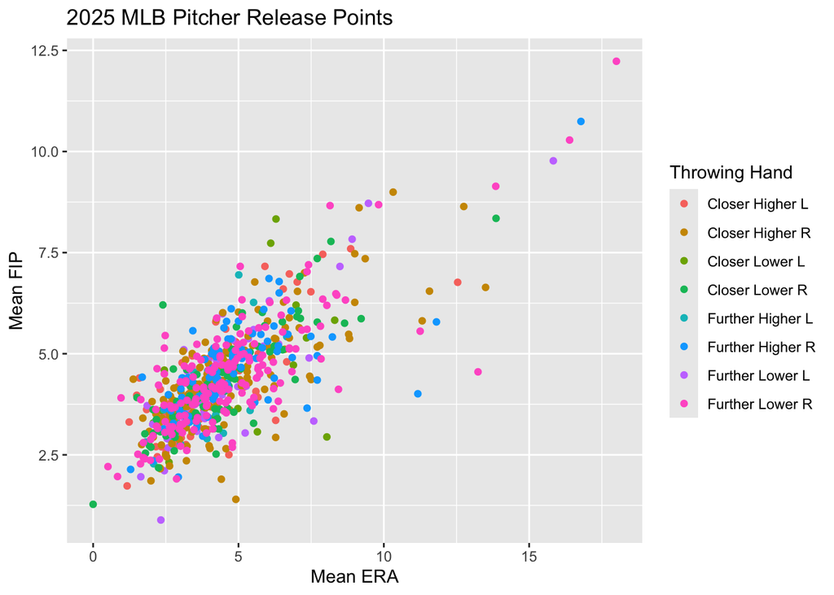

```r
release_positions = ggplot(groupings, aes(x = mean_era, y = mean_fip, color = Category))+ geom_point() + labs(x = "Mean ERA", y ="Mean FIP", title = "2025 MLB Pitcher Release Points", color = "Throwing Hand" )
release_positions
```

We then compared ERA, WHIP, FIP, and K/BB results across the eight release groupings.

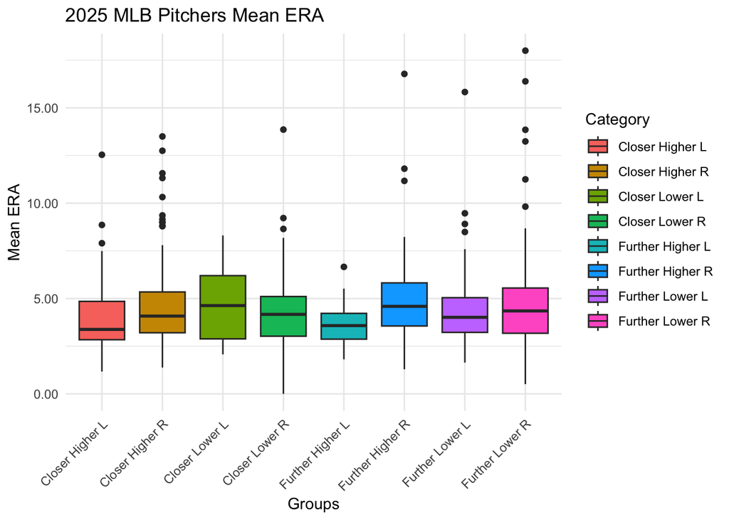

```r
era_rankings <- ggplot(groupings, aes(x = Category, y = mean_era, fill = Category)) +
  geom_boxplot() +
  labs(x = "Groups", y = "Mean ERA", title = "2025 MLB Pitchers Mean ERA"
  ) +
  scale_y_continuous(labels = scales::number_format(accuracy = 0.01)) +
  theme_minimal() +
  theme(axis.text.x = element_text(angle = 45, hjust = 1))

era_rankings
```

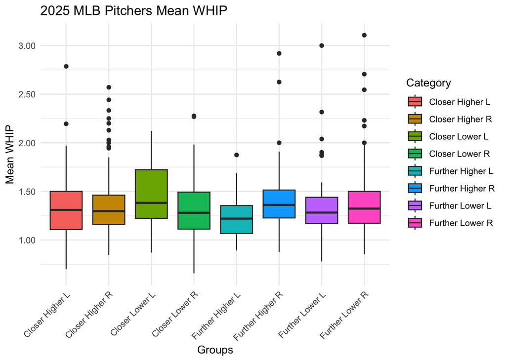

```r
whip_rankings <- ggplot(groupings, aes(x = Category, y = mean_whip, fill = Category)) +
  geom_boxplot() +
  labs(x = "Groups", y = "Mean WHIP", title = "2025 MLB Pitchers Mean WHIP"
  ) +
  scale_y_continuous(labels = scales::number_format(accuracy = 0.01)) +
  theme_minimal() +
  theme(axis.text.x = element_text(angle = 45, hjust = 1))

whip_rankings
```

[figure not shown]

```r
fip_rankings <- ggplot(groupings, aes(x = Category, y = mean_whip, fill = Category)) +
  geom_boxplot() +
  labs(x = "Groups", y = "Mean FIP", title = "2025 MLB Pitchers WHIP"
  ) +
  scale_y_continuous(labels = scales::number_format(accuracy = 0.01)) +
  theme_minimal() +
  theme(axis.text.x = element_text(angle = 45, hjust = 1))

fip_rankings
```

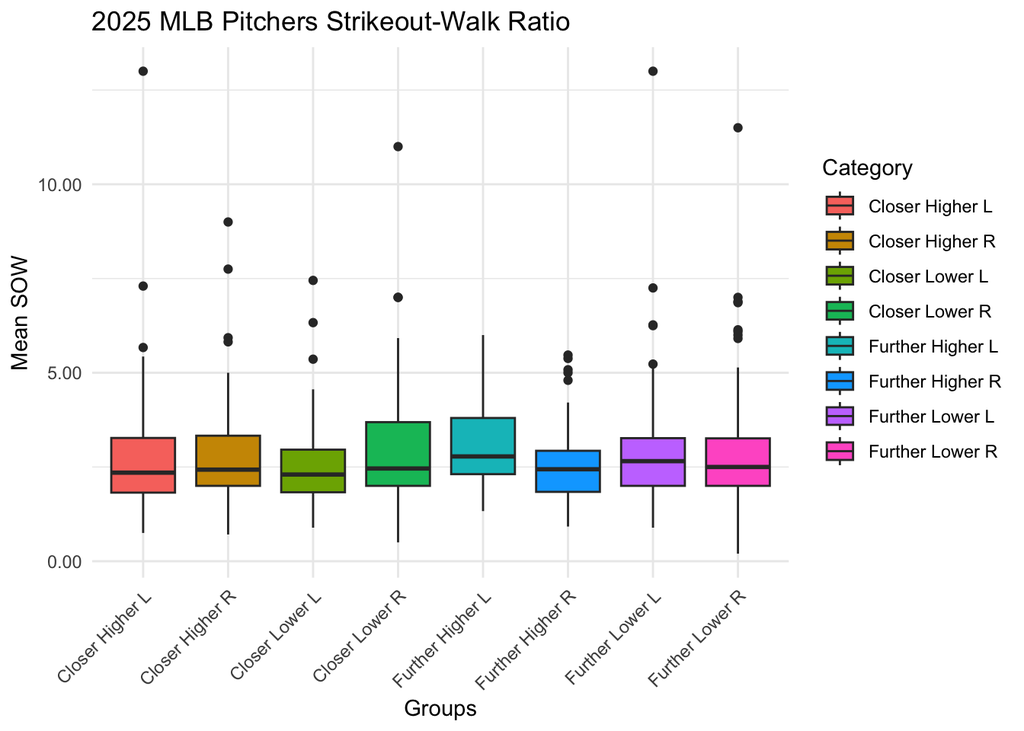

```r
sow_rankings <- ggplot(groupings, aes(x = Category, y = mean_sow, fill = Category)) +
  geom_boxplot() +
  labs(x = "Groups", y = "Mean SOW", title = "2025 MLB Pitchers Strikeout-Walk Ratio"
  ) +
  scale_y_continuous(labels = scales::number_format(accuracy = 0.01)) +
  theme_minimal() +
  theme(axis.text.x = element_text(angle = 45, hjust = 1))

sow_rankings
```

[figure not shown]

```r
era_four_group <- ggplot(groupings_no_hand, aes(x = Category, y = mean_era, color = Category)) +
  geom_point(size = 10) + geom_hline(yintercept = all_pitchers_means$mean_era) +
  labs(x = "Groups", y = "Mean FIP", title = "2025 MLB Pitchers Mean ERA"
  ) +
  scale_y_continuous(labels = scales::number_format(accuracy = 0.005)) +
  theme_minimal() +
  theme(axis.text.x = element_text(angle = 45, hjust = 1))

era_four_group
```

[figure not shown]

```r
whip_four_group <- ggplot(groupings_no_hand, aes(x = Category, y = mean_whip, color = Category)) +
  geom_point(size = 10) + geom_hline(yintercept = all_pitchers_means$mean_whip) +
  labs(x = "Groups", y = "Mean FIP", title = "2025 MLB Pitcher Release Points"
  ) +
  scale_y_continuous(labels = scales::number_format(accuracy = 0.001)) +
  theme_minimal() +
  theme(axis.text.x = element_text(angle = 45, hjust = 1))

whip_four_group
```

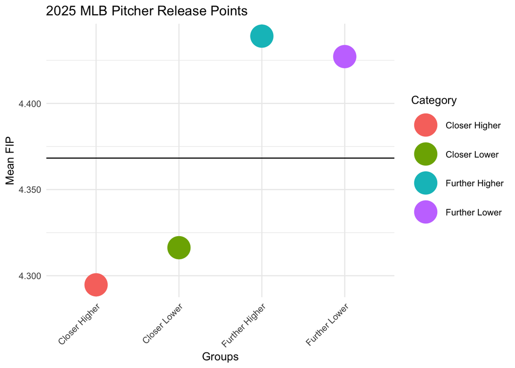

```r
fip_four_group <- ggplot(groupings_no_hand, aes(x = Category, y = mean_fip, color = Category)) +
  geom_point(size = 10) + geom_hline(yintercept = all_pitchers_means$mean_fip) +
  labs(x = "Groups", y = "Mean FIP", title = "2025 MLB Pitcher Release Points"
  ) +
  scale_y_continuous(labels = scales::number_format(accuracy = 0.001)) +
  theme_minimal() +
  theme(axis.text.x = element_text(angle = 45, hjust = 1))

fip_four_group
```

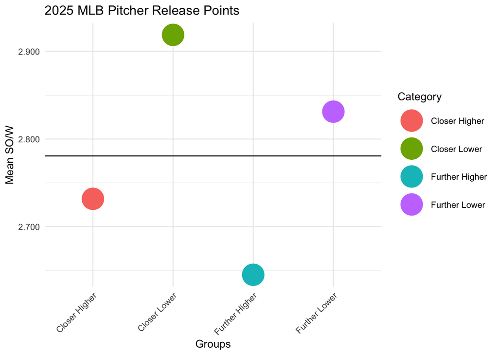

```r
sow_four_group <- ggplot(groupings_no_hand, aes(x = Category, y = mean_sow, color = Category)) +
  geom_point(size = 10) + geom_hline(yintercept = all_pitchers_means$mean_sow) +
  labs(x = "Groups", y = "Mean SO/W", title = "2025 MLB Pitcher Release Points"
  ) +
  scale_y_continuous(labels = scales::number_format(accuracy = 0.001)) +
  theme_minimal() +
  theme(axis.text.x = element_text(angle = 45, hjust = 1))

sow_four_group
```

### Top Players

We then wanted to see some of the names associated with these groups. Across each of the eight release groups, we looked at the top 5 pitchers for each of the four pitching metrics we chose. To no surprise, we saw some of the biggest names in the league at the top of these lists.

```r
rfh_pitchers = final_pitchers %>% rename(Name = Name.x) %>% filter(throwing_hand == "R", x_depth == "Further", z_depth == "Higher", IP > 50)

rfh_pitchers %>% arrange(ERA) %>% select(Name, ERA, IP, throwing_hand, x_depth, z_depth) %>% head(n=5)
```

```
## # A tibble: 5 × 6
##   Name             ERA    IP throwing_hand x_depth z_depth
##   <chr>          <dbl> <dbl> <chr>         <chr>   <chr>
## 1 Jhoan Durán     2.06  70   R             Further Higher
## 2 Hunter Brown    2.43 185.  R             Further Higher
## 3 Carlos Estévez  2.45  66   R             Further Higher
## 4 Eduard Bazardo  2.52  78.2 R             Further Higher
## 5 Kenley Jansen   2.59  59   R             Further Higher
```

```r
rfh_pitchers %>% arrange(WHIP) %>% select(Name, WHIP, IP, throwing_hand, x_depth, z_depth) %>% head(n=5)
```

```
## # A tibble: 5 × 6
##   Name            WHIP    IP throwing_hand x_depth z_depth
##   <chr>          <dbl> <dbl> <chr>         <chr>   <chr>
## 1 Hunter Greene  0.938 107.  R             Further Higher
## 2 Kenley Jansen  0.949  59   R             Further Higher
## 3 Cade Smith     1.00   73.2 R             Further Higher
## 4 Eduard Bazardo 1.02   78.2 R             Further Higher
## 5 Hunter Brown   1.02  185.  R             Further Higher
```

```r
rfh_pitchers %>% arrange(FIP) %>% select(Name, FIP, IP, throwing_hand, x_depth, z_depth) %>% head(n=5)
```

```
## # A tibble: 5 × 6
##   Name            FIP    IP throwing_hand x_depth z_depth
##   <chr>         <dbl> <dbl> <chr>         <chr>   <chr>
## 1 Cade Smith     1.95  73.2 R             Further Higher
## 2 Jhoan Durán    2.35  70   R             Further Higher
## 3 Hunter Brown   3.14 185.  R             Further Higher
## 4 Hunter Greene  3.28 107.  R             Further Higher
## 5 Luis García    3.31  54.1 R             Further Higher
```

```r
rfh_pitchers %>% arrange(desc(SO.W)) %>% select(Name, SO.W, IP, throwing_hand, x_depth, z_depth) %>% head(n=5)
```

```
## # A tibble: 5 × 6
##   Name            SO.W    IP throwing_hand x_depth z_depth
##   <chr>          <dbl> <dbl> <chr>         <chr>   <chr>
## 1 Cade Smith      5.47  73.2 R             Further Higher
## 2 Hunter Greene   5.08 107.  R             Further Higher
## 3 Jhoan Durán     4.21  70   R             Further Higher
## 4 Zebby Matthews  3.67  79.1 R             Further Higher
## 5 Tanner Gordon   3.65  75.1 R             Further Higher
```

```r
rfl_pitchers = final_pitchers %>% rename(Name = Name.x) %>% filter(throwing_hand == "R", x_depth == "Further", z_depth == "Lower", IP > 50)

rfl_pitchers %>% arrange(ERA) %>% select(Name, ERA, IP, throwing_hand, x_depth, z_depth) %>% head(n=5)
```

```
## # A tibble: 5 × 6
##   Name              ERA    IP throwing_hand x_depth z_depth
##   <chr>           <dbl> <dbl> <chr>         <chr>   <chr>
## 1 Edwin Díaz       1.63  66.1 R             Further Lower
## 2 Nathan Eovaldi   1.73 130   R             Further Lower
## 3 Andrés Muñoz     1.73  62.1 R             Further Lower
## 4 Randy Rodríguez  1.78  50.2 R             Further Lower
## 5 Paul Skenes      1.97 187.  R             Further Lower
```

```r
rfl_pitchers %>% arrange(WHIP) %>% select(Name, WHIP, IP, throwing_hand, x_depth, z_depth) %>% head(n=5)
```

```
## # A tibble: 5 × 6
##   Name             WHIP    IP throwing_hand x_depth z_depth
##   <chr>           <dbl> <dbl> <chr>         <chr>   <chr>
## 1 Nathan Eovaldi  0.854 130   R             Further Lower
## 2 Dennis Santana  0.867  70.1 R             Further Lower
## 3 Edwin Díaz      0.874  66.1 R             Further Lower
## 4 Randy Rodríguez 0.888  50.2 R             Further Lower
## 5 Zack Wheeler    0.935 149.  R             Further Lower
```

```r
rfl_pitchers %>% arrange(FIP) %>% select(Name, FIP, IP, throwing_hand, x_depth, z_depth) %>% head(n=5)
```

```
## # A tibble: 5 × 6
##   Name              FIP    IP throwing_hand x_depth z_depth
##   <chr>           <dbl> <dbl> <chr>         <chr>   <chr>
## 1 Edwin Díaz       2.28  66.1 R             Further Lower
## 2 Paul Skenes      2.37 187.  R             Further Lower
## 3 Bryan Abreu      2.39  71   R             Further Lower
## 4 Randy Rodríguez  2.40  50.2 R             Further Lower
## 5 Andrés Muñoz     2.43  62.1 R             Further Lower
```

```r
rfl_pitchers %>% arrange(desc(SO.W)) %>% select(Name, SO.W, IP, throwing_hand, x_depth, z_depth) %>% head(n=5)
```

```
## # A tibble: 5 × 6
##   Name                   SO.W    IP throwing_hand x_depth z_depth
##   <chr>                 <dbl> <dbl> <chr>         <chr>   <chr>
## 1 Tyler Rogers           6.86  77.1 R             Further Lower
## 2 Nathan Eovaldi         6.14 130   R             Further Lower
## 3 Randy Rodríguez        6.09  50.2 R             Further Lower
## 4 Spencer Schwellenbach  6    110.  R             Further Lower
## 5 Zack Wheeler           5.91 149.  R             Further Lower
```

```r
rch_pitchers = final_pitchers %>% rename(Name = Name.x) %>% filter(throwing_hand == "R", x_depth == "Closer", z_depth == "Higher", IP > 50)

rch_pitchers %>% arrange(ERA) %>% select(Name, ERA, IP, throwing_hand, x_depth, z_depth) %>% head(n=5)
```

```
## # A tibble: 5 × 6
##   Name           ERA    IP throwing_hand x_depth z_depth
##   <chr>        <dbl> <dbl> <chr>         <chr>   <chr>
## 1 Abner Uribe   1.67  75.1 R             Closer  Higher
## 2 Jason Adam    1.93  65.1 R             Closer  Higher
## 3 Brad Keller   2.07  69.2 R             Closer  Higher
## 4 David Bednar  2.3   62.2 R             Closer  Higher
## 5 Mike Vasil    2.5  101   R             Closer  Higher
```

```r
rch_pitchers %>% arrange(WHIP) %>% select(Name, WHIP, IP, throwing_hand, x_depth, z_depth) %>% head(n=5)
```

```
## # A tibble: 5 × 6
##   Name              WHIP    IP throwing_hand x_depth z_depth
##   <chr>            <dbl> <dbl> <chr>         <chr>   <chr>
## 1 Taylor Clarke    0.849  55.1 R             Closer  Higher
## 2 Robert Suarez    0.904  69.2 R             Closer  Higher
## 3 Mason Miller     0.908  61.2 R             Closer  Higher
## 4 Brandon Woodruff 0.912  64.2 R             Closer  Higher
## 5 Brad Keller      0.962  69.2 R             Closer  Higher
```

```r
rch_pitchers %>% arrange(FIP) %>% select(Name, FIP, IP, throwing_hand, x_depth, z_depth) %>% head(n=5)
```

```
## # A tibble: 5 × 6
##   Name               FIP    IP throwing_hand x_depth z_depth
##   <chr>            <dbl> <dbl> <chr>         <chr>   <chr>
## 1 David Bednar      2.17  62.2 R             Closer  Higher
## 2 Mason Miller      2.22  61.2 R             Closer  Higher
## 3 Graham Ashcraft   2.72  65.1 R             Closer  Higher
## 4 Abner Uribe       2.75  75.1 R             Closer  Higher
## 5 Braxton Ashcraft  2.78  69.2 R             Closer  Higher
```

```r
rch_pitchers %>% arrange(desc(SO.W)) %>% select(Name, SO.W, IP, throwing_hand, x_depth, z_depth) %>% head(n=5)
```

```
## # A tibble: 5 × 6
##   Name              SO.W    IP throwing_hand x_depth z_depth
##   <chr>            <dbl> <dbl> <chr>         <chr>   <chr>
## 1 Brandon Woodruff  5.93  64.2 R             Closer  Higher
## 2 Andrew Kittredge  5.82  53   R             Closer  Higher
## 3 Taylor Clarke     4.89  55.1 R             Closer  Higher
## 4 Bryan Baker       4.88  68.2 R             Closer  Higher
## 5 Robert Suarez     4.69  69.2 R             Closer  Higher
```

```r
rcl_pitchers = final_pitchers %>% rename(Name = Name.x) %>% filter(throwing_hand == "R", x_depth == "Closer", z_depth == "Lower", IP > 50)

rcl_pitchers %>% arrange(ERA) %>% select(Name, ERA, IP, throwing_hand, x_depth, z_depth) %>% head(n=5)
```

```
## # A tibble: 5 × 6
##   Name                 ERA    IP throwing_hand x_depth z_depth
##   <chr>              <dbl> <dbl> <chr>         <chr>   <chr>
## 1 Matt Svanson        1.94  60.1 R             Closer  Lower
## 2 Tyler Mahle         2.18  86.2 R             Closer  Lower
## 3 Garrett Whitlock    2.25  72   R             Closer  Lower
## 4 Shawn Armstrong     2.31  74   R             Closer  Lower
## 5 Yoshinobu Yamamoto  2.51 168.  R             Closer  Lower
```

```r
rcl_pitchers %>% arrange(WHIP) %>% select(Name, WHIP, IP, throwing_hand, x_depth, z_depth) %>% head(n=5)
```

```
## # A tibble: 5 × 6
##   Name             WHIP    IP throwing_hand x_depth z_depth
##   <chr>           <dbl> <dbl> <chr>         <chr>   <chr>
## 1 Shawn Armstrong 0.811  74   R             Closer  Lower
## 2 Matt Svanson    0.878  60.1 R             Closer  Lower
## 3 Emilio Pagán    0.917  68.2 R             Closer  Lower
## 4 Jacob deGrom    0.921 172.  R             Closer  Lower
## 5 Bryan Woo       0.927 186.  R             Closer  Lower
```

```r
rcl_pitchers %>% arrange(FIP) %>% select(Name, FIP, IP, throwing_hand, x_depth, z_depth) %>% head(n=5)
```

```
## # A tibble: 5 × 6
##   Name               FIP    IP throwing_hand x_depth z_depth
##   <chr>            <dbl> <dbl> <chr>         <chr>   <chr>
## 1 Garrett Whitlock  2.18  72   R             Closer  Lower
## 2 Griffin Jax       2.52  66   R             Closer  Lower
## 3 Phil Maton        2.6   61.1 R             Closer  Lower
## 4 Matt Svanson      2.72  60.1 R             Closer  Lower
## 5 Emmet Sheehan     2.94  73.1 R             Closer  Lower
```

```r
rcl_pitchers %>% arrange(desc(SO.W)) %>% select(Name, SO.W, IP, throwing_hand, x_depth, z_depth) %>% head(n=5)
```

```
## # A tibble: 5 × 6
##   Name           SO.W    IP throwing_hand x_depth z_depth
##   <chr>         <dbl> <dbl> <chr>         <chr>   <chr>
## 1 Janson Junk    5.92  110  R             Closer  Lower
## 2 Logan Gilbert  5.58  131  R             Closer  Lower
## 3 Bryan Woo      5.5   186. R             Closer  Lower
## 4 Sonny Gray     5.29  180. R             Closer  Lower
## 5 Jacob deGrom   5     172. R             Closer  Lower
```

```r
lfh_pitchers = final_pitchers %>% rename(Name = Name.x) %>% filter(throwing_hand == "L", x_depth == "Further", z_depth == "Higher", IP > 50)

lfh_pitchers %>% arrange(ERA) %>% select(Name, ERA, IP, throwing_hand, x_depth, z_depth) %>% head(n=5)
```

```
## # A tibble: 5 × 6
##   Name              ERA    IP throwing_hand x_depth z_depth
##   <chr>           <dbl> <dbl> <chr>         <chr>   <chr>
## 1 Trevor Rogers    1.81 109.  L             Further Higher
## 2 Adrián Morejón   2.08  73.2 L             Further Higher
## 3 Brant Hurter     2.43  63   L             Further Higher
## 4 Garrett Crochet  2.59 205.  L             Further Higher
## 5 Sean Newcomb     2.73  92.1 L             Further Higher
```

```r
lfh_pitchers %>% arrange(WHIP) %>% select(Name, WHIP, IP, throwing_hand, x_depth, z_depth) %>% head(n=5)
```

```
## # A tibble: 5 × 6
##   Name             WHIP    IP throwing_hand x_depth z_depth
##   <chr>           <dbl> <dbl> <chr>         <chr>   <chr>
## 1 Steven Okert    0.893  71.2 L             Further Higher
## 2 Adrián Morejón  0.896  73.2 L             Further Higher
## 3 Trevor Rogers   0.903 109.  L             Further Higher
## 4 Tanner Banks    1.01   67.1 L             Further Higher
## 5 Garrett Crochet 1.03  205.  L             Further Higher
```

```r
lfh_pitchers %>% arrange(FIP) %>% select(Name, FIP, IP, throwing_hand, x_depth, z_depth) %>% head(n=5)
```

```
## # A tibble: 5 × 6
##   Name              FIP    IP throwing_hand x_depth z_depth
##   <chr>           <dbl> <dbl> <chr>         <chr>   <chr>
## 1 Adrián Morejón   2.28  73.2 L             Further Higher
## 2 Steven Okert     2.76  71.2 L             Further Higher
## 3 Trevor Rogers    2.82 109.  L             Further Higher
## 4 Garrett Crochet  2.89 205.  L             Further Higher
## 5 Jesús Luzardo    2.9  183.  L             Further Higher
```

```r
lfh_pitchers %>% arrange(desc(SO.W)) %>% select(Name, SO.W, IP, throwing_hand, x_depth, z_depth) %>% head(n=5)
```

```
## # A tibble: 5 × 6
##   Name             SO.W    IP throwing_hand x_depth z_depth
##   <chr>           <dbl> <dbl> <chr>         <chr>   <chr>
## 1 Garrett Crochet  5.54 205.  L             Further Higher
## 2 Tanner Banks     5.08  67.1 L             Further Higher
## 3 Jose Ferrer      4.44  76.1 L             Further Higher
## 4 Steven Okert     4.42  71.2 L             Further Higher
## 5 Adrián Morejón   4.12  73.2 L             Further Higher
```

```r
lfl_pitchers = final_pitchers %>% rename(Name = Name.x) %>% filter(throwing_hand == "L", x_depth == "Further", z_depth == "Lower", IP > 50)

lfl_pitchers %>% arrange(ERA) %>% select(Name, ERA, IP, throwing_hand, x_depth, z_depth) %>% head(n=5)
```

```
## # A tibble: 5 × 6
##   Name          ERA    IP throwing_hand x_depth z_depth
##   <chr>       <dbl> <dbl> <chr>         <chr>   <chr>
## 1 Josh Hader   2.05  52.2 L             Further Lower
## 2 Kris Bubic   2.55 116.  L             Further Lower
## 3 Chris Sale   2.58 125.  L             Further Lower
## 4 Matt Strahm  2.74  62.1 L             Further Lower
## 5 Bryan King   2.78  68   L             Further Lower
```

```r
lfl_pitchers %>% arrange(WHIP) %>% select(Name, WHIP, IP, throwing_hand, x_depth, z_depth) %>% head(n=5)
```

```
## # A tibble: 5 × 6
##   Name            WHIP    IP throwing_hand x_depth z_depth
##   <chr>          <dbl> <dbl> <chr>         <chr>   <chr>
## 1 Josh Hader     0.854  52.2 L             Further Lower
## 2 Brandon Walter 0.932  53.2 L             Further Lower
## 3 Shota Imanaga  0.988 140.  L             Further Lower
## 4 Bryan King     1.04   68   L             Further Lower
## 5 Chris Sale     1.07  125.  L             Further Lower
```

```r
lfl_pitchers %>% arrange(FIP) %>% select(Name, FIP, IP, throwing_hand, x_depth, z_depth) %>% head(n=5)
```

```
## # A tibble: 5 × 6
##   Name               FIP    IP throwing_hand x_depth z_depth
##   <chr>            <dbl> <dbl> <chr>         <chr>   <chr>
## 1 Chris Sale        2.68 125.  L             Further Lower
## 2 Kris Bubic        2.90 116.  L             Further Lower
## 3 Justin Wrobleski  2.93  66.2 L             Further Lower
## 4 Matt Strahm       3.00  62.1 L             Further Lower
## 5 Josh Hader        3.26  52.2 L             Further Lower
```

```r
lfl_pitchers %>% arrange(desc(SO.W)) %>% select(Name, SO.W, IP, throwing_hand, x_depth, z_depth) %>% head(n=5)
```

```
## # A tibble: 5 × 6
##   Name            SO.W    IP throwing_hand x_depth z_depth
##   <chr>          <dbl> <dbl> <chr>         <chr>   <chr>
## 1 Brandon Walter 13     53.2 L             Further Lower
## 2 Bryan King      6.27  68   L             Further Lower
## 3 Sean Manaea     6.25  60.2 L             Further Lower
## 4 Shota Imanaga   5.23 140.  L             Further Lower
## 5 Chris Sale      5.16 125.  L             Further Lower
```

```r
lch_pitchers = final_pitchers %>% rename(Name = Name.x) %>% filter(throwing_hand == "L", x_depth == "Closer", z_depth == "Higher", IP > 50)

lch_pitchers %>% arrange(ERA) %>% select(Name, ERA, IP, throwing_hand, x_depth, z_depth) %>% head(n=5)
```

```
## # A tibble: 5 × 6
##   Name                 ERA    IP throwing_hand x_depth z_depth
##   <chr>              <dbl> <dbl> <chr>         <chr>   <chr>
## 1 Aroldis Chapman     1.17  61.1 L             Closer  Higher
## 2 Aaron Ashby         2.16  66.2 L             Closer  Higher
## 3 Tarik Skubal        2.21 195.  L             Closer  Higher
## 4 Blake Snell         2.35  61.1 L             Closer  Higher
## 5 Cristopher Sánchez  2.5  202   L             Closer  Higher
```

```r
lch_pitchers %>% arrange(WHIP) %>% select(Name, WHIP, IP, throwing_hand, x_depth, z_depth) %>% head(n=5)
```

```
## # A tibble: 5 × 6
##   Name             WHIP    IP throwing_hand x_depth z_depth
##   <chr>           <dbl> <dbl> <chr>         <chr>   <chr>
## 1 Aroldis Chapman 0.701  61.1 L             Closer  Higher
## 2 Tarik Skubal    0.891 195.  L             Closer  Higher
## 3 Caleb Thielbar  0.895  57   L             Closer  Higher
## 4 Alex Vesia      0.972  58.2 L             Closer  Higher
## 5 Dylan Lee       0.98   68.1 L             Closer  Higher
```

```r
lch_pitchers %>% arrange(FIP) %>% select(Name, FIP, IP, throwing_hand, x_depth, z_depth) %>% head(n=5)
```

```
## # A tibble: 5 × 6
##   Name                 FIP    IP throwing_hand x_depth z_depth
##   <chr>              <dbl> <dbl> <chr>         <chr>   <chr>
## 1 Aroldis Chapman     1.73  61.1 L             Closer  Higher
## 2 Tarik Skubal        2.45 195.  L             Closer  Higher
## 3 Cole Ragans         2.50  61.2 L             Closer  Higher
## 4 Cristopher Sánchez  2.56 202   L             Closer  Higher
## 5 Blake Snell         2.70  61.1 L             Closer  Higher
```

```r
lch_pitchers %>% arrange(desc(SO.W)) %>% select(Name, SO.W, IP, throwing_hand, x_depth, z_depth) %>% head(n=5)
```

```
## # A tibble: 5 × 6
##   Name                SO.W    IP throwing_hand x_depth z_depth
##   <chr>              <dbl> <dbl> <chr>         <chr>   <chr>
## 1 Tarik Skubal        7.3  195.  L             Closer  Higher
## 2 Aroldis Chapman     5.67  61.1 L             Closer  Higher
## 3 Dylan Lee           5.43  68.1 L             Closer  Higher
## 4 Cole Ragans         4.9   61.2 L             Closer  Higher
## 5 Cristopher Sánchez  4.82 202   L             Closer  Higher
```

```r
lcl_pitchers = final_pitchers %>% rename(Name = Name.x) %>% filter(throwing_hand == "L", x_depth == "Closer", z_depth == "Lower", IP > 50)

lcl_pitchers %>% arrange(ERA) %>% select(Name, ERA, IP, throwing_hand, x_depth, z_depth) %>% head(n=5)
```

```
## # A tibble: 5 × 6
##   Name                 ERA    IP throwing_hand x_depth z_depth
##   <chr>              <dbl> <dbl> <chr>         <chr>   <chr>
## 1 JoJo Romero         2.07  61   L             Closer  Lower
## 2 Garrett Cleavinger  2.35  61.1 L             Closer  Lower
## 3 Gabe Speier         2.61  62   L             Closer  Lower
## 4 Kolby Allard        2.63  65   L             Closer  Lower
## 5 Steven Matz         3.05  76.2 L             Closer  Lower
```

```r
lcl_pitchers %>% arrange(WHIP) %>% select(Name, WHIP, IP, throwing_hand, x_depth, z_depth) %>% head(n=5)
```

```
## # A tibble: 5 × 6
##   Name                WHIP    IP throwing_hand x_depth z_depth
##   <chr>              <dbl> <dbl> <chr>         <chr>   <chr>
## 1 Gabe Speier        0.871  62   L             Closer  Lower
## 2 Garrett Cleavinger 0.946  61.1 L             Closer  Lower
## 3 Steven Matz        1.10   76.2 L             Closer  Lower
## 4 Martín Pérez       1.11   56   L             Closer  Lower
## 5 Kolby Allard       1.2    65   L             Closer  Lower
```

```r
lcl_pitchers %>% arrange(FIP) %>% select(Name, FIP, IP, throwing_hand, x_depth, z_depth) %>% head(n=5)
```

```
## # A tibble: 5 × 6
##   Name           FIP    IP throwing_hand x_depth z_depth
##   <chr>        <dbl> <dbl> <chr>         <chr>   <chr>
## 1 Gabe Speier   2.32  62   L             Closer  Lower
## 2 JoJo Romero   3.29  61   L             Closer  Lower
## 3 Gregory Soto  3.42  60.1 L             Closer  Lower
## 4 Steven Matz   3.47  76.2 L             Closer  Lower
## 5 Kolby Allard  3.54  65   L             Closer  Lower
```

```r
lcl_pitchers %>% arrange(desc(SO.W)) %>% select(Name, SO.W, IP, throwing_hand, x_depth, z_depth) %>% head(n=5)
```

```
## # A tibble: 5 × 6
##   Name                SO.W    IP throwing_hand x_depth z_depth
##   <chr>              <dbl> <dbl> <chr>         <chr>   <chr>
## 1 Gabe Speier         7.45  62   L             Closer  Lower
## 2 Steven Matz         5.36  76.2 L             Closer  Lower
## 3 Garrett Cleavinger  4.56  61.1 L             Closer  Lower
## 4 JP Sears            3.25 135.  L             Closer  Lower
## 5 Kolby Allard        3     65   L             Closer  Lower
```

### Linear model

Finally, we created four linear models to test the statistical significance of our results. Each one we compared one of the four pitching metrics to throwing hand, x_depth, and z_depth.

```r
summary(lm(ERA ~ throwing_hand + x_depth + z_depth, data = final_pitchers))
```

```
##
## Call:
## lm(formula = ERA ~ throwing_hand + x_depth + z_depth, data = final_pitchers)
##
## Residuals:
##     Min      1Q  Median      3Q     Max
## -4.5772 -1.3572 -0.4038  0.8228 13.2569
##
## Coefficients:
##                Estimate Std. Error t value Pr(>|t|)
## (Intercept)     4.10273    0.19112  21.467   <2e-16 ***
## throwing_handR  0.45107    0.19247   2.344   0.0194 *
## x_depthFurther  0.16589    0.17880   0.928   0.3539
## z_depthLower    0.02336    0.17899   0.131   0.8962
## ---
## Signif. codes:  0 '***' 0.001 '**' 0.01 '*' 0.05 '.' 0.1 ' ' 1
##
## Residual standard error: 2.191 on 665 degrees of freedom
## Multiple R-squared:  0.01013,    Adjusted R-squared:  0.00566
## F-statistic: 2.267 on 3 and 665 DF,  p-value: 0.0795
```

```r
summary(lm(WHIP ~ throwing_hand + x_depth + z_depth, data = final_pitchers))
```

```
##
## Call:
## lm(formula = WHIP ~ throwing_hand + x_depth + z_depth, data = final_pitchers)
##
## Residuals:
##      Min       1Q   Median       3Q      Max
## -0.70201 -0.19675 -0.05018  0.12682  1.73382
##
## Coefficients:
##                Estimate Std. Error t value Pr(>|t|)
## (Intercept)    1.341521   0.028194  47.581   <2e-16 ***
## throwing_handR 0.013229   0.028394   0.466    0.641
## x_depthFurther 0.015169   0.026377   0.575    0.565
## z_depthLower   0.003259   0.026405   0.123    0.902
## ---
## Signif. codes:  0 '***' 0.001 '**' 0.01 '*' 0.05 '.' 0.1 ' ' 1
##
## Residual standard error: 0.3232 on 665 degrees of freedom
## Multiple R-squared:  0.001027,   Adjusted R-squared:  -0.00348
## F-statistic: 0.2279 on 3 and 665 DF,  p-value: 0.877
```

```r
summary(lm(FIP ~ throwing_hand + x_depth + z_depth, data = final_pitchers))
```

```
##
## Call:
## lm(formula = FIP ~ throwing_hand + x_depth + z_depth, data = final_pitchers)
##
## Residuals:
##     Min      1Q  Median      3Q     Max
## -3.3930 -0.8136 -0.1905  0.6403  7.7533
##
## Coefficients:
##                 Estimate Std. Error t value Pr(>|t|)
## (Intercept)     4.163492   0.116231  35.821   <2e-16 ***
## throwing_handR  0.195701   0.117054   1.672    0.095 .
## x_depthFurther  0.124374   0.108741   1.144    0.253
## z_depthLower   -0.005823   0.108855  -0.053    0.957
## ---
## Signif. codes:  0 '***' 0.001 '**' 0.01 '*' 0.05 '.' 0.1 ' ' 1
##
## Residual standard error: 1.332 on 665 degrees of freedom
## Multiple R-squared:  0.006528,   Adjusted R-squared:  0.002046
## F-statistic: 1.457 on 3 and 665 DF,  p-value: 0.2253
```

```r
summary(lm(SO.W ~ throwing_hand + x_depth + z_depth, data = final_pitchers))
```

```
##
## Call:
## lm(formula = SO.W ~ throwing_hand + x_depth + z_depth, data = final_pitchers)
##
## Residuals:
##     Min      1Q  Median      3Q     Max
## -2.5832 -0.8391 -0.2832  0.5072 10.1213
##
## Coefficients:
##                Estimate Std. Error t value Pr(>|t|)
## (Intercept)     2.87873    0.12393  23.229   <2e-16 ***
## throwing_handR -0.20964    0.12480  -1.680   0.0935 .
## x_depthFurther -0.08333    0.11594  -0.719   0.4726
## z_depthLower    0.19743    0.11606   1.701   0.0894 .
## ---
## Signif. codes:  0 '***' 0.001 '**' 0.01 '*' 0.05 '.' 0.1 ' ' 1
##
## Residual standard error: 1.421 on 665 degrees of freedom
## Multiple R-squared:  0.008168,   Adjusted R-squared:  0.003693
## F-statistic: 1.825 on 3 and 665 DF,  p-value: 0.1412
```